##Reproducible Research

#Peer Assessment 1

#2014-05-19

#Loading and preprocessing the data

- Load the data
- Process/transform the data

```r
## Dependencies

## Set file locations
setwd("~/Documents/reproducibleresearch/")

## Read data
stepdat <- read.csv(unz("repdata-data-activity.zip", "activity.csv"))
```

#What is mean total number of steps taken per day?

- Histogram of total number of steps taken each day
- Mean and median total number of steps taken each day

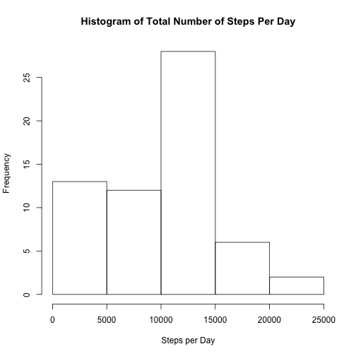

```r
## Aggregate by day and display histogram
stepsperday <- aggregate(stepdat$steps, by = list(as.numeric(as.Date(stepdat$date))),
    FUN = sum, na.rm = TRUE)
hist(stepsperday[, 2], main = "Histogram of Total Number of Steps Per Day",
    ylab = "Frequency", xlab = "Steps per Day")
```

```r
## Mean and median
stepsum <- summary(stepsperday[, 2])
```

The mean and median number of steps per day are 9350 and 1.04 × 10<sup>4</sup> respectively.

#What is the average daily activity pattern?

- Time series plot
- Which 5 minute interval contains maximum # of steps?

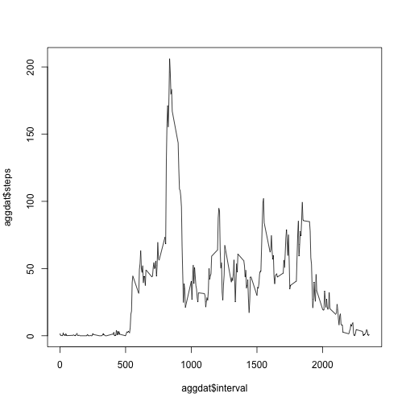

```r
aggdat <- aggregate(stepdat, by = list(stepdat$interval), FUN = mean, na.rm = TRUE)
plot(x = aggdat$interval, y = aggdat$steps, type = "l")
```

```r
maxint <- aggdat[which(aggdat$steps == max(aggdat$steps)), ]$interval
```

The interval containing, on average, the maximum numer of steps is 835.

#Imputing missing values

- Calculate and report total number of rows with missing values
- Devise imputation strategy
- Create new data set with missing values imputed
- Histogram of total steps per day, calculate mean and median steps per day

```r
missrows <- sum(is.na(stepdat))
```

A total of 2304 rows contain missing values.

*Imputation strategy*

Replace missing values with observed mean for that interval. A more sophisticated approach can be found in package mtsdi.

Code below replaces missing values.

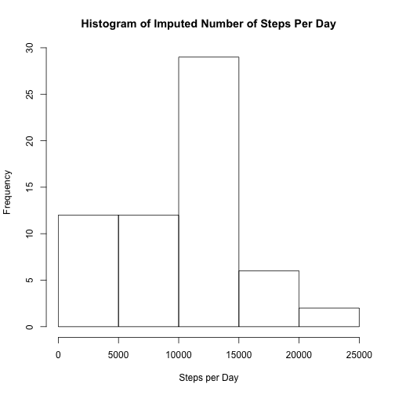

```r
stepdat2 <- stepdat
toreplace <- is.na(stepdat2)
for (i in 1:dim(toreplace)[1]) {
    if (toreplace == TRUE) {
        stepdat2$steps[which(toreplace)] <- aggdat$steps[which(aggdat$interval ==
            stepdat2$interval[which(toreplace)])]
    }
}

## Aggregate imputed data by day
stepsperday2 <- aggregate(stepdat2$steps, by = list(as.numeric(as.Date(stepdat2$date))),
    FUN = sum, na.rm = TRUE)
hist(stepsperday2[, 2], main = "Histogram of Imputed Number of Steps Per Day",
    ylab = "Frequency", xlab = "Steps per Day")
```

```r
## Mean and median
stepsum2 <- summary(stepsperday2[, 2])
```

The mean and median number of steps per day are 9530 and 1.04 × 10<sup>4</sup> respectively.

#Weekday/Weekend Differences

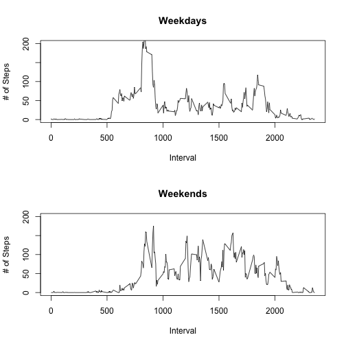

```r
stepdat2$weekday <- as.factor(weekdays(as.Date(stepdat2$date)) == "Saturday" |
    weekdays(as.Date(stepdat2$date)) == "Sunday")

stepdat3 <- split(stepdat2, stepdat2$weekday)
aggdat3a <- aggregate(stepdat3[[1]], by = list(stepdat3[[1]]$interval), FUN = mean,
    na.rm = TRUE)
aggdat3b <- aggregate(stepdat3[[2]], by = list(stepdat3[[2]]$interval), FUN = mean,
    na.rm = TRUE)

par(mfrow = c(2, 1))
plot(x = aggdat3a$interval, y = aggdat3a$steps, type = "l", ylab = "# of Steps",
    xlab = "Interval", main = "Weekdays", ylim = c(0, 200))
plot(x = aggdat3b$interval, y = aggdat3b$steps, type = "l", ylab = "# of Steps",
    xlab = "Interval", main = "Weekends", ylim = c(0, 200))
```